# IE582 - HW 1

Anıl Turgut - 2022702072

2023-10-29

## Introduction

In this assignment, I will do a study on data analysis and applications on 60 different stocks in Borsa Istanbul, their closing prices and corresponding time periods.

Data analysis under different headings, preprocessing, PCA application and correlation analyzes will be performed when necessary.

### Task 4.0 : Loading required libraries and data.

At first, We loaded the data to the R Environment to complete the parts of the question. Also, loaded some libraries providing the visualizations to interpret the data.

```r
library(ggplot2)
library(caret)
library(data.table)
library(zoo)
library(GGally)
library(gridExtra)
```

Note that the `path` is set to the folder in my computer. Please change it to run the commands properly.

```r
long <- data.table(read.csv("C:/Users/anil.turgut/Desktop/IE582/HW1/Dataset/all_ticks_long.csv"))

wide <- data.table(read.csv("C:/Users/anil.turgut/Desktop/IE582/HW1/Dataset/all_ticks_wide.csv"))

columns_wide <- colnames(wide)

dim(wide)
```

```
## [1] 50012    61
```

There are 60 stock columns and a timestamp column. Also, almost 15 min interval of instances (approximately 50000) occur in the data.

### Task 4.1 : Descriptive Analysis

Let’s begin by exploring data in terms of type, statistics, NA values etc.

When we look at the summary of the `wide` dataset of stocks, all the stock prices are defined as number type of data and the `timestamp` column is a type of chr. There are missing values in data, we are going to analyze these columns with missing values following.

```r
str(wide)
```

```
## Classes 'data.table' and 'data.frame':   50012 obs. of  61 variables:
##  $ timestamp: chr  "2012-09-17T06:45:00Z" "2012-09-17T07:00:00Z" "2012-09-17T07:15:00Z" "2012-09-17T07:30:00Z" ...
##  $ AEFES    : num  22.4 22.4 22.4 22.4 22.6 ...
##  $ AKBNK    : num  5.21 5.19 5.21 5.19 5.21 ...
##  $ AKSA     : num  1.71 1.71 1.71 1.71 1.71 ...
##  $ AKSEN    : num  3.87 3.86 NA 3.86 3.87 3.86 NA 3.86 NA 3.86 ...
##  $ ALARK    : num  1.47 1.46 1.46 1.45 1.46 ...
##  $ ALBRK    : num  1.14 1.13 1.14 1.13 1.14 ...
##  $ ANACM    : num  1.06 1.06 1.07 1.07 1.07 ...
##  $ ARCLK    : num  6.99 6.93 6.99 6.96 6.99 ...
##  $ ASELS    : num  2.99 2.99 2.99 2.99 2.98 ...
##  $ ASUZU    : num  2.5 2.51 2.48 2.49 2.49 ...
##  $ AYGAZ    : num  3.54 3.55 3.55 3.54 3.54 ...
##  $ BAGFS    : num  37.5 37.3 37.3 37.4 37.5 ...
##  $ BANVT    : num  3.95 3.96 3.96 3.95 3.96 3.95 3.96 3.96 3.95 3.95 ...
```

[output cut: 48 more lines]

Since we are going to use the `timestamp` of the records in data analysis, we need to change its type from character to datetime (POSIX). Let’s do this transformation:

```r
wide$timestamp <- as.POSIXct(wide$timestamp, format = "%Y-%m-%dT%H:%M:%SZ", tz = "UTC")
class(wide$timestamp)
```

```
## [1] "POSIXct" "POSIXt"
```

It worked well, let’s move on with the statistics of the stocks and timestamp:

When we examine the data summary, we see the average, minimum and maximum values of the stocks from 2012 to 2019. There are two problems I noticed at this point:

- There seems to be a possibility of anomaly values in many stocks such as AEFES, AKBNK, ARCLK, because there is a serious gap between min and max values, except for means and quartiles. These should be examined in more detail during visualization and action should be taken when necessary.
- A missing value appears in each stock column, and the main reason for this is that there is no corresponding data in the relevant timestamps. We also need to handle missing values for future applications such as PCA.

```r
summary(wide)
```

```
##    timestamp                          AEFES             AKBNK
##  Min.   :2012-09-17 06:45:00.00   Min.   : 0.0001   Min.   :0.0001
##  1st Qu.:2014-08-12 13:11:15.00   1st Qu.:19.1605   1st Qu.:5.8500
##  Median :2016-05-13 11:22:30.00   Median :20.6465   Median :6.3057
##  Mean   :2016-04-12 21:51:05.74   Mean   :20.9822   Mean   :6.4731
##  3rd Qu.:2017-12-22 11:03:45.00   3rd Qu.:22.7320   3rd Qu.:6.9325
##  Max.   :2019-07-23 15:00:00.00   Max.   :28.5090   Max.   :9.2124
##                                   NA's   :1881      NA's   :803
##       AKSA             AKSEN           ALARK            ALBRK
##  Min.   : 0.0001   Min.   :0.000   Min.   :0.0001   Min.   :1.026
##  1st Qu.: 5.2088   1st Qu.:2.670   1st Qu.:1.5689   1st Qu.:1.225
##  Median : 6.9853   Median :2.930   Median :1.9376   Median :1.360
##  Mean   : 7.1275   Mean   :3.183   Mean   :2.0609   Mean   :1.365
##  3rd Qu.: 8.7200   3rd Qu.:3.750   3rd Qu.:2.4214   3rd Qu.:1.500
##  Max.   :15.1189   Max.   :5.190   Max.   :3.5143   Max.   :2.190
##  NA's   :1418      NA's   :1841    NA's   :1677     NA's   :3150
##      ANACM            ARCLK             ASELS             ASUZU
##  Min.   :0.0001   Min.   : 0.0001   Min.   : 0.0001   Min.   : 0.0001
##  1st Qu.:1.0470   1st Qu.:11.7111   1st Qu.: 4.9403   1st Qu.: 5.0748
##  Median :1.2597   Median :15.0100   Median : 9.2757   Median : 5.9496
##  Mean   :1.6721   Mean   :15.3881   Mean   :13.4325   Mean   : 6.4670
##  3rd Qu.:2.4021   3rd Qu.:19.0877   3rd Qu.:22.7567   3rd Qu.: 7.1200
##  Max.   :3.5021   Max.   :26.4278   Max.   :46.7616   Max.   :15.2800
##  NA's   :1847     NA's   :967       NA's   :1209      NA's   :1579
##      AYGAZ             BAGFS             BANVT            BRISA
##  Min.   : 0.0001   Min.   : 0.0001   Min.   : 0.000   Min.   : 0.0001
##  1st Qu.: 5.9515   1st Qu.: 8.2618   1st Qu.: 2.590   1st Qu.: 5.8900
##  Median : 7.7238   Median :10.6100   Median : 3.710   Median : 6.7300
##  Mean   : 8.1019   Mean   :10.4071   Mean   : 7.628   Mean   : 6.5449
##  3rd Qu.:10.2690   3rd Qu.:12.3500   3rd Qu.:11.930   3rd Qu.: 7.3300
##  Max.   :13.5935   Max.   :38.4352   Max.   :28.680   Max.   :10.3275
##  NA's   :1893      NA's   :1362      NA's   :2061     NA's   :1075
##      CCOLA             CEMAS           ECILC            EREGL
##  Min.   : 0.0001   Min.   :0.000   Min.   :0.0001   Min.   : 0.0001
##  1st Qu.:31.9782   1st Qu.:0.700   1st Qu.:1.1723   1st Qu.: 2.1812
##  Median :34.8215   Median :0.870   Median :1.8214   Median : 3.0360
##  Mean   :36.8907   Mean   :1.209   Mean   :2.0759   Mean   : 4.1795
##  3rd Qu.:42.0497   3rd Qu.:1.500   3rd Qu.:2.7809   3rd Qu.: 6.7587
##  Max.   :54.2208   Max.   :7.010   Max.   :4.2278   Max.   :10.4710
##  NA's   :1263      NA's   :3618    NA's   :1520     NA's   :839
```

[output cut: 73 more lines]

```
##  Min.   :0.0001   Min.   : 0.000   Min.   : 0.000   Min.   :0.0001
##  1st Qu.:4.0322   1st Qu.: 4.020   1st Qu.: 0.389   1st Qu.:2.2682
##  Median :4.4742   Median : 6.320   Median : 0.966   Median :2.6093
##  Mean   :4.7354   Mean   : 5.943   Mean   : 2.434   Mean   :2.5663
##  3rd Qu.:5.2460   3rd Qu.: 7.450   3rd Qu.: 4.230   3rd Qu.:2.8740
##  Max.   :7.5814   Max.   :14.540   Max.   :10.675   Max.   :3.9581
##  NA's   :800      NA's   :1231     NA's   :3957     NA's   :787
##      YUNSA           ZOREN
##  Min.   :0.000   Min.   :0.0001
##  1st Qu.:3.007   1st Qu.:1.0338
##  Median :4.108   Median :1.2500
##  Mean   :4.080   Mean   :1.2481
##  3rd Qu.:4.721   3rd Qu.:1.4265
##  Max.   :9.528   Max.   :2.4430
##  NA's   :4484    NA's   :1205
```

```r
cat("Value of 368th AEFES record before NA Handling -> ",wide$AEFES[368],"\n")
```

```
## Value of 368th AEFES record before NA Handling ->  NA
```

```r
selected_columns <- wide[0:length(wide),2:61]
colnames(selected_columns)
```

```
##  [1] "AEFES" "AKBNK" "AKSA"  "AKSEN" "ALARK" "ALBRK" "ANACM" "ARCLK" "ASELS"
## [10] "ASUZU" "AYGAZ" "BAGFS" "BANVT" "BRISA" "CCOLA" "CEMAS" "ECILC" "EREGL"
## [19] "FROTO" "GARAN" "GOODY" "GUBRF" "HALKB" "ICBCT" "ISCTR" "ISDMR" "ISFIN"
## [28] "ISYAT" "KAREL" "KARSN" "KCHOL" "KRDMB" "KRDMD" "MGROS" "OTKAR" "PARSN"
## [37] "PETKM" "PGSUS" "PRKME" "SAHOL" "SASA"  "SISE"  "SKBNK" "SODA"  "TCELL"
## [46] "THYAO" "TKFEN" "TOASO" "TRKCM" "TSKB"  "TTKOM" "TUKAS" "TUPRS" "USAK"
## [55] "VAKBN" "VESTL" "YATAS" "YKBNK" "YUNSA" "ZOREN"
```

```r
window_size <- 5

# Apply na.approx() to fill missing values in each column
for (columnName in colnames(selected_columns)) {
  if(any(is.na(wide[[columnName]]))){
    wide[[columnName]] <- na.approx(wide[[columnName]], method = "linear", rule = window(window_size))
  }
}

cat("Value of 368th AEFES record after NA Handling -> ",wide$AEFES[368],"\n")
```

```
## Value of 368th AEFES record after NA Handling ->  22.5858
```

```r
colSums(is.na(wide))
```

```
## timestamp     AEFES     AKBNK      AKSA     AKSEN     ALARK     ALBRK     ANACM
##         0         0         0         0         0         0         0         0
##     ARCLK     ASELS     ASUZU     AYGAZ     BAGFS     BANVT     BRISA     CCOLA
##         0         0         0         0         0         0         0         0
##     CEMAS     ECILC     EREGL     FROTO     GARAN     GOODY     GUBRF     HALKB
##         0         0         0         0         0         0         0         0
##     ICBCT     ISCTR     ISDMR     ISFIN     ISYAT     KAREL     KARSN     KCHOL
##         0         0         0         0         0         0         0         0
##     KRDMB     KRDMD     MGROS     OTKAR     PARSN     PETKM     PGSUS     PRKME
##         0         0         0         0         0         0         0         0
##     SAHOL      SASA      SISE     SKBNK      SODA     TCELL     THYAO     TKFEN
##         0         0         0         0         0         0         0         0
##     TOASO     TRKCM      TSKB     TTKOM     TUKAS     TUPRS      USAK     VAKBN
##         0         0         0         0         0         0         0         0
##     VESTL     YATAS     YKBNK     YUNSA     ZOREN
##         0         0         0         0         0
```

As can be seen in above, there is no missing value in our data from now on. So, we need to handle the second problem which is the anomaly records. Let’s visualize the two stocks prices which are the two of my preferred stocks, and see how the anomaly values look like. Visualizations and anomaly points of `AEFES` and `CCOLA` can be seen below:

Note that I defined threshold value as: mean - 3 stdev || almost zero. If it is less than this threshold, I conclude with anomaly point.

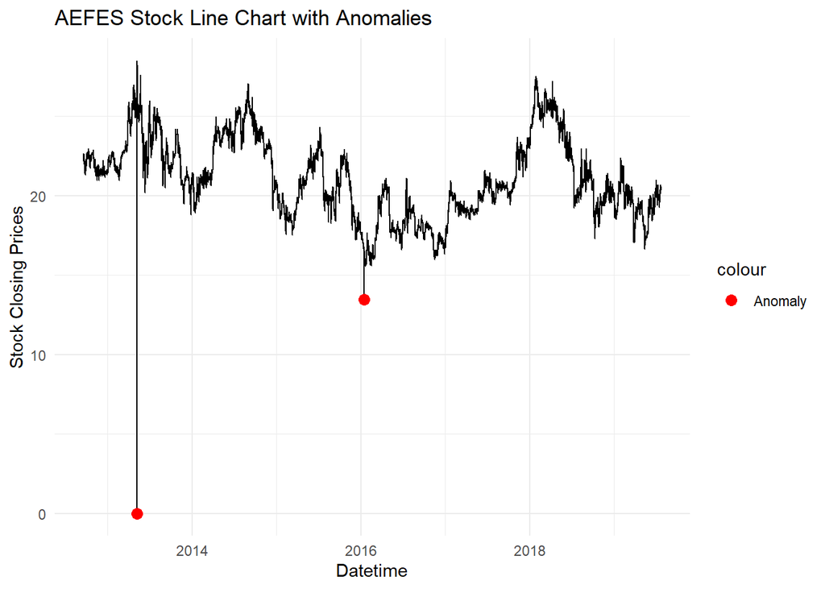

```r
anomaly_threshold_aefes <-  mean(wide$AEFES) - 3 * sqrt(var(wide$AEFES)) # Adjust this threshold as needed
anomaly_values_aefes <- wide$AEFES < anomaly_threshold_aefes

# Create a line chart with ggplot2 and highlight anomaly values
ggplot(wide, aes(x = timestamp, y = AEFES)) +
  geom_line() +
  geom_point(data = wide[anomaly_values_aefes, ], aes(color = "Anomaly"), size = 3) +
  labs(x = "Datetime", y = "Stock Closing Prices", title = "AEFES Stock Line Chart with Anomalies") +
  scale_color_manual(values = c("Anomaly" = "red")) +
  theme_minimal()
```

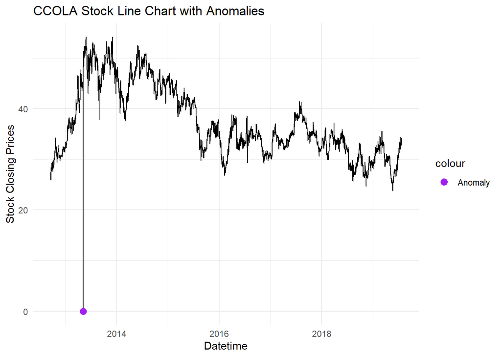

```r
anomaly_threshold_ccola <-  mean(wide$CCOLA) - 3 * sqrt(var(wide$CCOLA)) # Adjust this threshold as needed
anomaly_values_ccola <- wide$CCOLA < anomaly_threshold_ccola

# Create a line chart with ggplot2 and highlight anomaly values
ggplot(wide, aes(x = timestamp, y = CCOLA)) +
  geom_line() +
  geom_point(data = wide[anomaly_values_ccola, ], aes(color = "Anomaly"), size = 3) +
  labs(x = "Datetime", y = "Stock Closing Prices", title = "CCOLA Stock Line Chart with Anomalies") +
  scale_color_manual(values = c("Anomaly" = "purple")) +
  theme_minimal()
```

As can be clearly seen from both graphs, there is a point where the value has almost reached 0. This point is as we see at the min value in other stocks. It might have been caused by a momentary outage in that timestamp.

It might be a better idea to try to fix the error rather than dropping this anomaly value directly. Therefore, below is a script that will solve this situation by averaging the values in the previous and next index.

Also, I have selected the following 5 stocks to deeply analyze and make applications on. They are: `AEFES`, `AKSA`, `CCOLA`, `SISE`, `KCHOL`

After running the script, the anomaly values are replaced with +-1 index’s mean and visualizations make more sense.

```r
selectedStockPairs <- c("AEFES","AKSA","CCOLA","SISE","KCHOL")

isAnomaly <- function(columnName, index){

  flag <- FALSE

  currentCellValue <- wide[[columnName]][index]

  thresholdValue <- mean(wide[[columnName]]) - 3 * sqrt(var(wide[[columnName]]))

  if (currentCellValue < thresholdValue || currentCellValue < 0.5) {
    flag <- TRUE
  }
  return(flag)
}

for (columnName in selectedStockPairs){
  for (ind in 1:nrow(wide)){
    if(isAnomaly(columnName,ind)){
      cat("Old value in ",columnName," -> Index: ",ind," -> ", "Value: ", wide[[columnName]][ind],"\n")
      wide[[columnName]][ind] <- round(mean(wide[[columnName]][ind - 1: ind + 1], na.rm = TRUE), digits = 4)
      cat("New value in ",columnName," -> Index: ",ind," -> ", "Value: ", wide[[columnName]][ind],"\n")
    }
  }
}
```

```
## Old value in  AEFES  -> Index:  4160  ->  Value:  1e-04
## New value in  AEFES  -> Index:  4160  ->  Value:  22.5686
## Old value in  AEFES  -> Index:  22388  ->  Value:  13.4782
## New value in  AEFES  -> Index:  22388  ->  Value:  21.9887
## Old value in  AKSA  -> Index:  4160  ->  Value:  1e-04
## New value in  AKSA  -> Index:  4160  ->  Value:  1.953
## Old value in  CCOLA  -> Index:  4160  ->  Value:  1e-04
## New value in  CCOLA  -> Index:  4160  ->  Value:  35.1992
## Old value in  SISE  -> Index:  4160  ->  Value:  1e-04
## New value in  SISE  -> Index:  4160  ->  Value:  1.0508
## Old value in  KCHOL  -> Index:  4160  ->  Value:  1e-04
## New value in  KCHOL  -> Index:  4160  ->  Value:  7.595
```

Now, visualizing the final plots of these 5 stocks is as following:

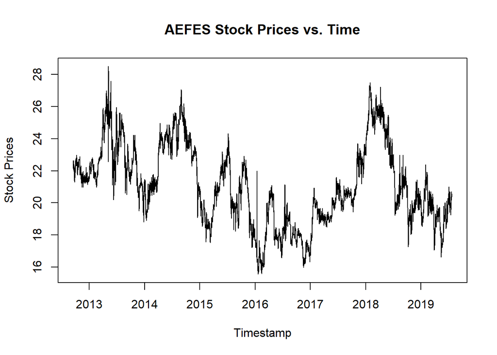

```r
plot(wide$timestamp, wide$AEFES, type = "l", xlab = "Timestamp", ylab = "Stock Prices", main = "AEFES Stock Prices vs. Time")
```

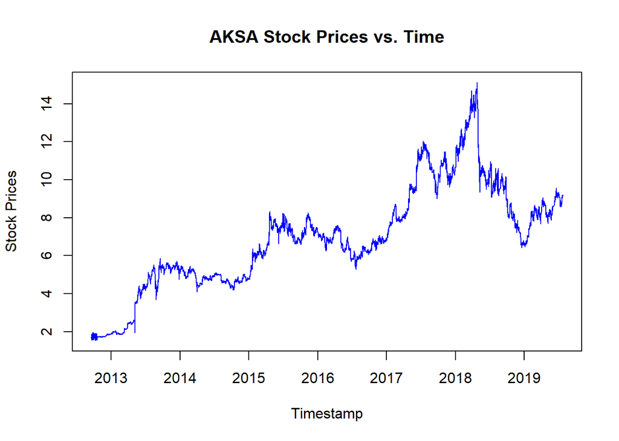

```r
plot(wide$timestamp, wide$AKSA, type = "l", xlab = "Timestamp", ylab = "Stock Prices",col = "blue", main = "AKSA Stock Prices vs. Time")
```

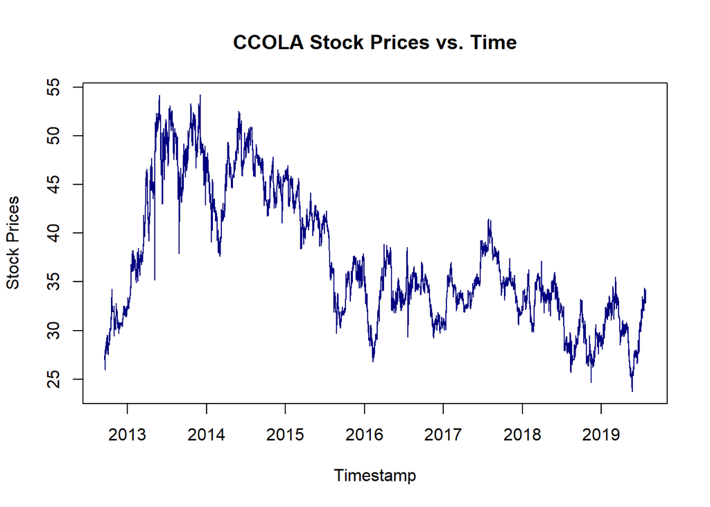

```r
plot(wide$timestamp, wide$CCOLA, type = "l", xlab = "Timestamp", ylab = "Stock Prices",col = "navyblue", main = "CCOLA Stock Prices vs. Time")
```

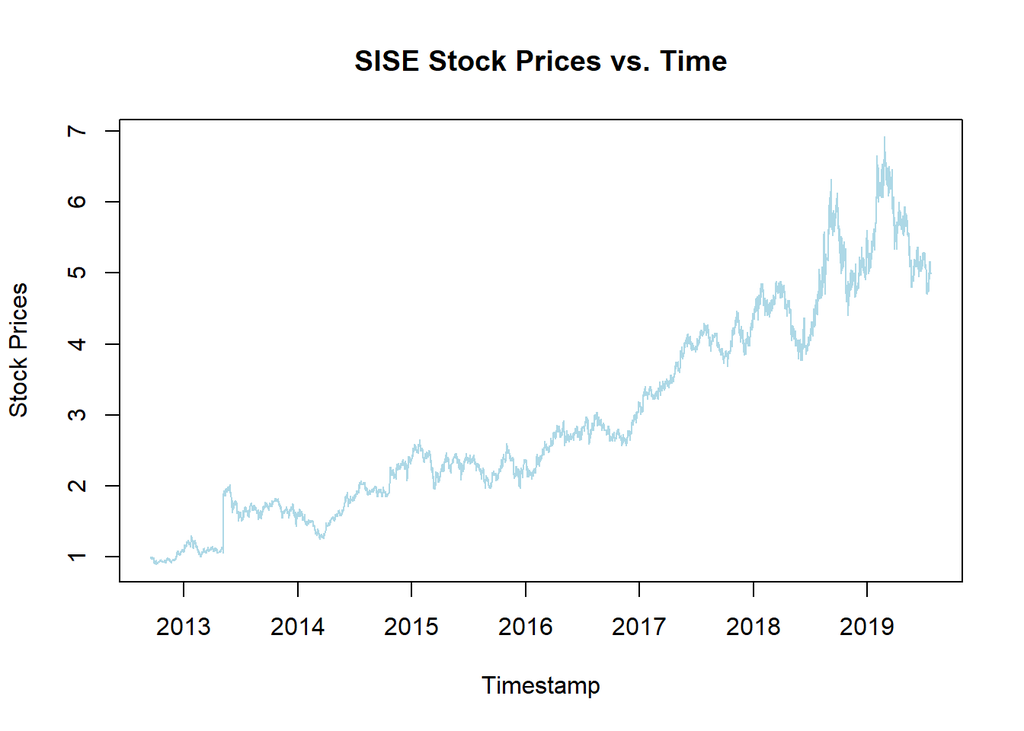

```r
plot(wide$timestamp, wide$SISE, type = "l", xlab = "Timestamp", ylab = "Stock Prices",col = "lightblue", main = "SISE Stock Prices vs. Time")
```

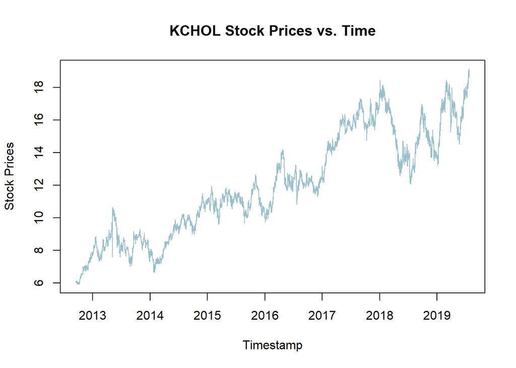

```r
plot(wide$timestamp, wide$KCHOL, type = "l", xlab = "Timestamp", ylab = "Stock Prices",col = "lightblue3", main = "KCHOL Stock Prices vs. Time")
```

Let’s do the final analysis of the data in terms of descriptive analysis. Let’s print some useful information of 5 stocks such as price range, standard deviation etc. And then visualize their histogram plots to see whether their values are skewed or not.

```r
print("Descriptive summary analysis")
```

```
## [1] "Descriptive summary analysis"
```

```r
for (col in selectedStockPairs){
  cat("Column Name: ", col, "\n")
  cat("Minimum Price: ", min(wide[[col]]), "\n")
  cat("Maximum Price: ", max(wide[[col]]), "\n")
  cat("Price Range: ",max(wide[[col]]) -  min(wide[[col]]), "\n")
  cat("Median Price: ", median(wide[[col]]), "\n")
  cat("Average Price: ", mean(wide[[col]]), "\n")
  cat("Stdev of Price: ", sd(wide[[col]]), "\n")
  cat("-------------------","\n")

}
```

```
## Column Name:  AEFES
## Minimum Price:  15.5546
## Maximum Price:  28.509
## Price Range:  12.9544
## Median Price:  20.671
## Average Price:  21.00039
## Stdev of Price:  2.485818
## -------------------
## Column Name:  AKSA
## Minimum Price:  1.5268
## Maximum Price:  15.1189
## Price Range:  13.5921
## Median Price:  6.9784
## Average Price:  7.09903
## Stdev of Price:  2.721273
## -------------------
## Column Name:  CCOLA
## Minimum Price:  23.7252
## Maximum Price:  54.2208
## Price Range:  30.4956
## Median Price:  34.8403
## Average Price:  36.88041
## Stdev of Price:  6.733983
## -------------------
## Column Name:  SISE
## Minimum Price:  0.8881
## Maximum Price:  6.923
## Price Range:  6.0349
## Median Price:  2.6682
## Average Price:  3.051658
## Stdev of Price:  1.425534
## -------------------
## Column Name:  KCHOL
## Minimum Price:  5.9145
## Maximum Price:  19.15
## Price Range:  13.2355
## Median Price:  12.0356
## Average Price:  12.24812
## Stdev of Price:  3.181846
## -------------------
```

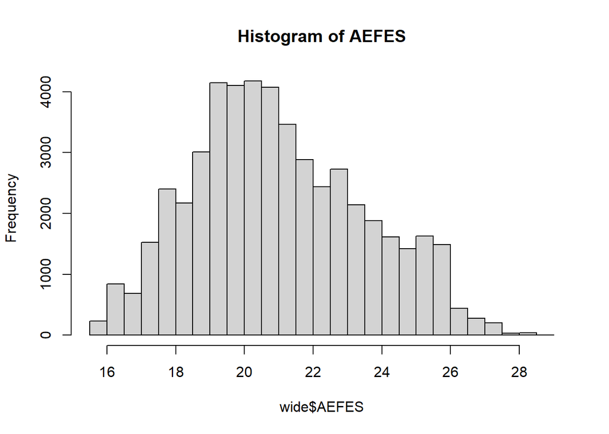

```r
hist(wide$AEFES,breaks = 20, main = "Histogram of AEFES")
```

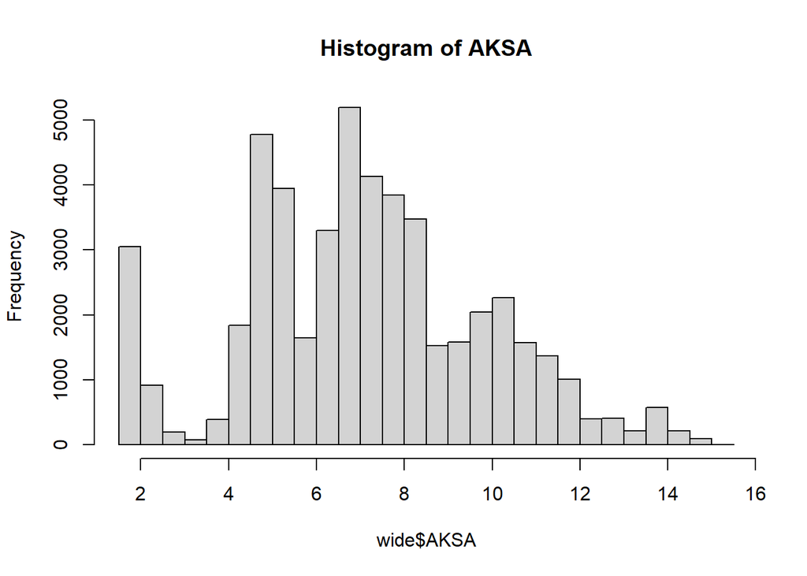

```r
hist(wide$AKSA, breaks = 20, main = "Histogram of AKSA")
```

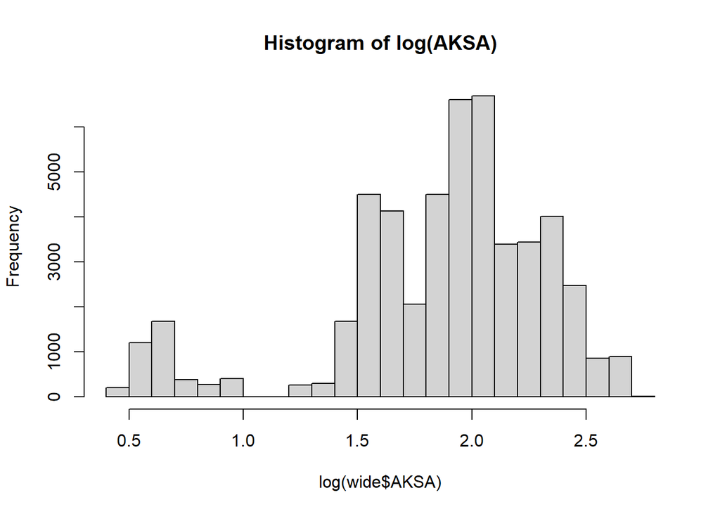

```r
hist(log(wide$AKSA), breaks = 20, main = "Histogram of log(AKSA)")
```

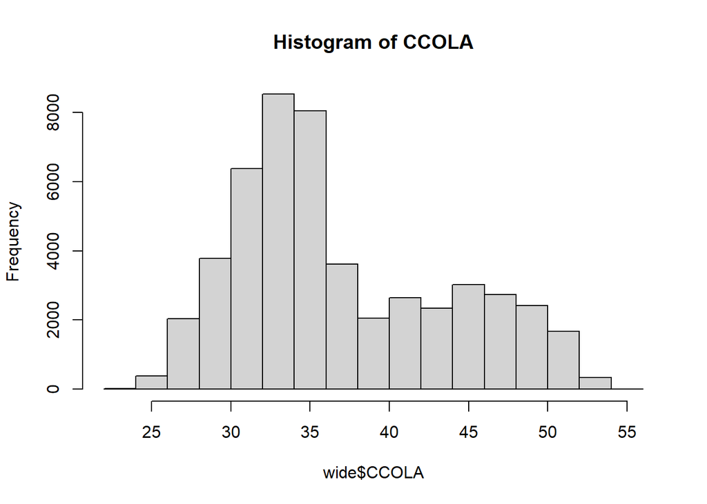

```r
hist(wide$CCOLA,breaks = 20, main = "Histogram of CCOLA")
```

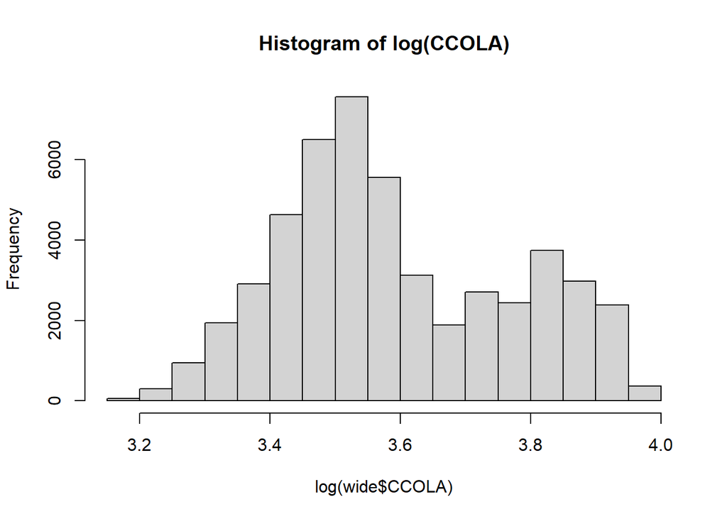

```r
hist(log(wide$CCOLA), breaks = 20, main = "Histogram of log(CCOLA)")
```

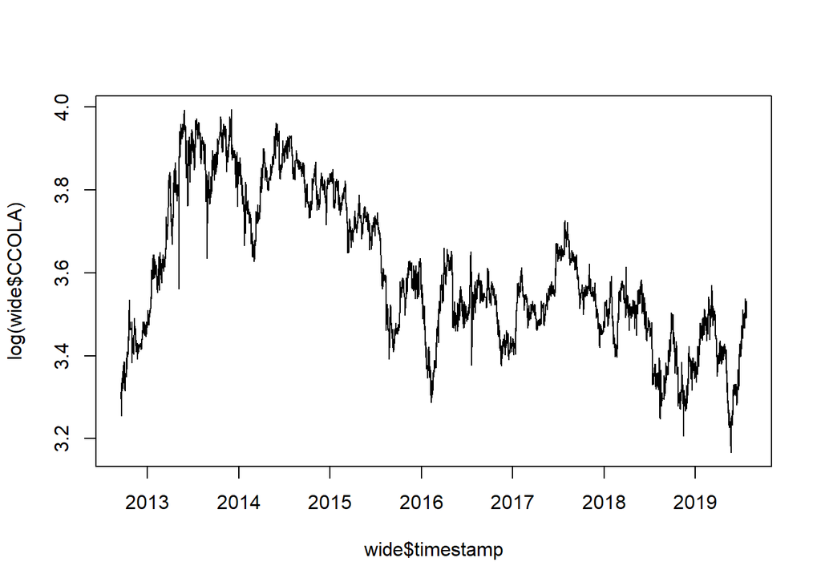

```r
plot(x=wide$timestamp,y=log(wide$CCOLA),type="l")
```

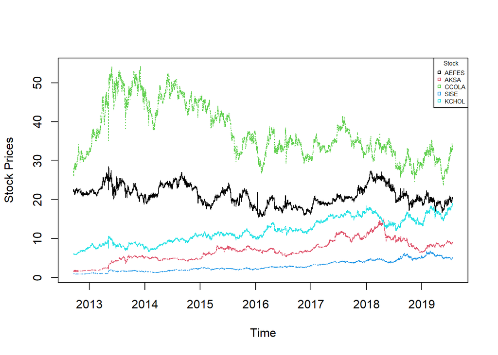

```r
wide_temp <- wide[,c("timestamp","AEFES","AKSA","CCOLA","SISE","KCHOL")]

wide_combined <- data.frame( "AEFES" = wide_temp[,"AEFES"],
                      "AKSA" = wide_temp[,"AKSA"],
                        "CCOLA" = wide_temp[,"CCOLA"],
                          "SISE" = wide_temp[,"SISE"],
                            "KCHOL" = wide_temp[,"KCHOL"])
matplot(x = wide_temp$timestamp,y = wide_combined, type = "l",pch=1,col = 1:5,
        xlab = "Time", ylab = "Stock Prices")
legend("topright", legend = c("AEFES","AKSA","CCOLA","SISE","KCHOL"), col=1:5,pch=0.2,title = "Stock", cex = 0.5)
```

It can be seen that the prices of AEFES looks like rightly skewed, however in AKSA or CCOLA, we cannot say neither they are right or left skewed. Moreover, we also looked their log() values in histogram and line chart. It is kind of improved but not completed.

For now, our date is ready to move on with the further tasks.

### Task 4.2 : Moving Window Correlation

Starting with the choosing the pairs of stock prices interested. In the previous task, I have selected some stocks to work deeply on and moving on these selections also.

Let’s filtered out the whole dataframe to the columns we need.

Also, I have created two new columns indicating the year and the month (as string) information which we are going to used in window correlations.

```r
wide_filtered <- wide[,c("timestamp","AEFES","AKSA","CCOLA","SISE","KCHOL")]

wide_filtered$Year <- format(wide_filtered$timestamp, format = "%Y")
wide_filtered$Month <- month.name[as.numeric(format(wide_filtered$timestamp, format = "%m"))]

wide_filtered <- wide_filtered[, c("timestamp","Year","Month","AEFES","AKSA","CCOLA","SISE","KCHOL")]
head(wide_filtered)
```

```
##              timestamp Year     Month   AEFES   AKSA   CCOLA   SISE  KCHOL
## 1: 2012-09-17 06:45:00 2012 September 22.3978 1.7102 27.2590 0.9932 6.0642
## 2: 2012-09-17 07:00:00 2012 September 22.3978 1.7066 27.3471 0.9897 6.0475
## 3: 2012-09-17 07:15:00 2012 September 22.3978 1.7102 27.3471 0.9932 6.0475
## 4: 2012-09-17 07:30:00 2012 September 22.3978 1.7102 27.4347 0.9897 6.0475
## 5: 2012-09-17 07:45:00 2012 September 22.5649 1.7102 27.4347 0.9970 6.0309
## 6: 2012-09-17 08:00:00 2012 September 22.5649 1.7102 27.4347 0.9970 6.0143
```

Now, our dataframe is ready to be analysed. In below, correlation matrix between each columns and 2 visualizations of correlation graphs of each pair of stocks can be seen.

```r
cor(wide_filtered[,c("AEFES","AKSA","CCOLA","SISE","KCHOL")])
```

```
##             AEFES        AKSA      CCOLA       SISE      KCHOL
## AEFES  1.00000000 -0.01256607  0.4806557 -0.1459433 -0.1498320
## AKSA  -0.01256607  1.00000000 -0.4111660  0.7676366  0.8396695
## CCOLA  0.48065571 -0.41116595  1.0000000 -0.5870795 -0.5421046
## SISE  -0.14594326  0.76763664 -0.5870795  1.0000000  0.9164088
## KCHOL -0.14983199  0.83966948 -0.5421046  0.9164088  1.0000000
```

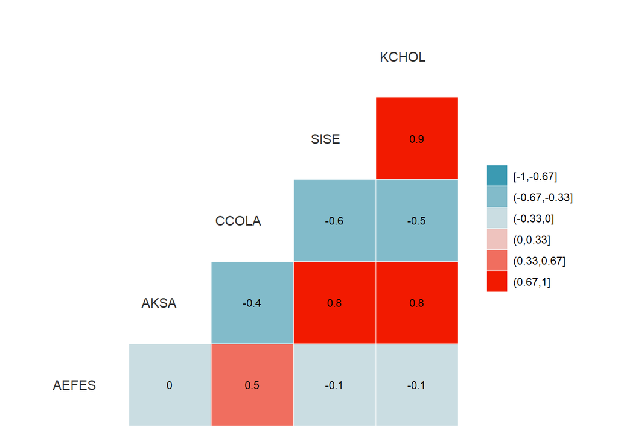

```r
ggcorr(wide_filtered,
       method = c("pairwise"),
       nbreaks = 6,
       hjust = 0.8,
       label = TRUE,
       label_size = 3,
       color = "grey20")
```

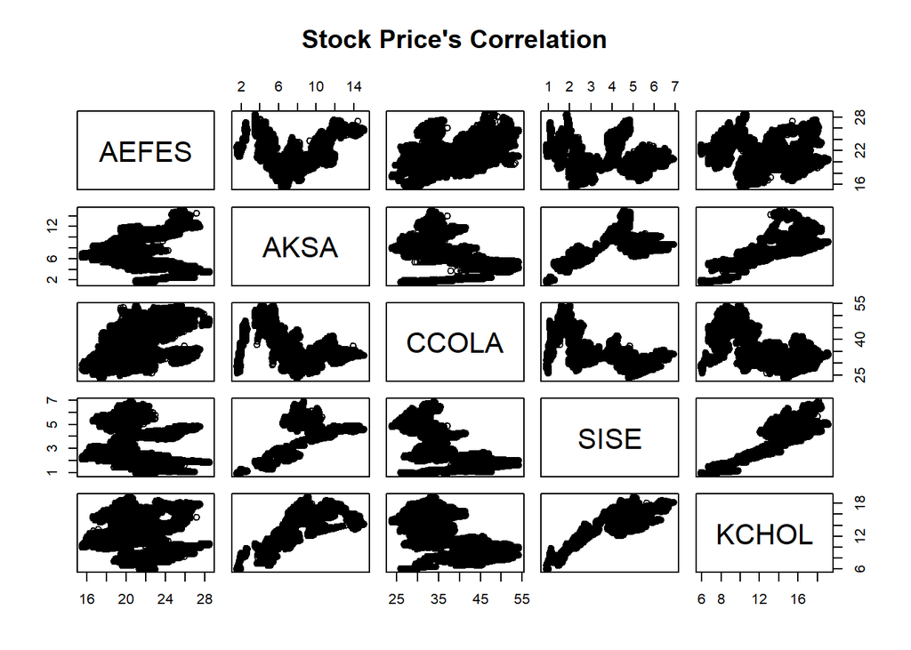

```r
plot(~ AEFES + AKSA + CCOLA + SISE + KCHOL, data = wide_filtered, main = "Stock Price's Correlation")
```

As it can be seen in the second plot, scatter plot of the [`KCHOL`,`SISE`] and [`KCHOL`,`AKSA`] shows us a meaningful pattern in terms of linearity.

In this part, I have commented out the correlation graphs. Printed out the monthly/yearly correlations instead of using graphs. But, it can be printed out by commenting-out.

```r
monthList <- unique(wide_filtered$Month)
yearList <- unique(wide_filtered$Year)

movingWindowCorr <- function(windowType,uniqueList){

    if(windowType == "Month"){
      for (month in uniqueList){
        filt <- subset(wide_filtered, Month == month)
        #cat(month,": ", round(cor(filt$SISE,filt$KCHOL),digits=4), "\n" )
        cat("*-------  ",month,"\n")
        print(cor(filt[,c("AEFES","AKSA","CCOLA","SISE","KCHOL")]))
        print("*------------------------------*")
        # plotCorr <-ggcorr(filt,
        #                   method = c("pairwise"),
        #                   nbreaks = 6,
        #                   hjust = 0.8,
        #                   label = TRUE,
        #                   label_size = 3,
        #                   label_round = 3,
        #                   color = "grey20")
        # print(plotCorr)
      }
    } else if (windowType == "Year"){

      for (year in uniqueList){
        filt <- subset(wide_filtered, Year == year)
        cat("*-------  ",year,"\n")
        print(cor(filt[,c("AEFES","AKSA","CCOLA","SISE","KCHOL")]))
        print("*------------------------------*")
        # plotCorr <-ggcorr(filt,
        #                   method = c("pairwise"),
        #                   nbreaks = 6,
        #                   hjust = 0.8,
        #                   label = TRUE,
        #                   label_size = 3,
        #                   label_round = 3,
        #                   color = "grey20")
        # print(plotCorr)
      }
    }

}

movingWindowCorr("Month",monthList)
```

```
## *-------   September
##            AEFES       AKSA      CCOLA       SISE      KCHOL
## AEFES  1.0000000 -0.3501464  0.5810042 -0.2103895 -0.3246128
## AKSA  -0.3501464  1.0000000 -0.3568300  0.8736812  0.9455840
## CCOLA  0.5810042 -0.3568300  1.0000000 -0.4601416 -0.3607078
## SISE  -0.2103895  0.8736812 -0.4601416  1.0000000  0.8895522
## KCHOL -0.3246128  0.9455840 -0.3607078  0.8895522  1.0000000
## [1] "*------------------------------*"
## *-------   October
##            AEFES       AKSA      CCOLA       SISE      KCHOL
## AEFES  1.0000000 -0.5036086  0.5675442 -0.6165392 -0.6344863
## AKSA  -0.5036086  1.0000000 -0.1760675  0.8244488  0.9419880
## CCOLA  0.5675442 -0.1760675  1.0000000 -0.4030976 -0.3485116
## SISE  -0.6165392  0.8244488 -0.4030976  1.0000000  0.9493420
## KCHOL -0.6344863  0.9419880 -0.3485116  0.9493420  1.0000000
## [1] "*------------------------------*"
## *-------   November
##            AEFES       AKSA      CCOLA       SISE      KCHOL
## AEFES  1.0000000 -0.0712707  0.4741386 -0.1071460 -0.0543172
## AKSA  -0.0712707  1.0000000 -0.1703625  0.7984445  0.9253906
## CCOLA  0.4741386 -0.1703625  1.0000000 -0.4677855 -0.3834472
## SISE  -0.1071460  0.7984445 -0.4677855  1.0000000  0.9378904
## KCHOL -0.0543172  0.9253906 -0.3834472  0.9378904  1.0000000
## [1] "*------------------------------*"
## *-------   December
##             AEFES        AKSA      CCOLA        SISE      KCHOL
## AEFES  1.00000000 -0.02342509  0.2242545  0.06043956  0.1661613
## AKSA  -0.02342509  1.00000000 -0.2563666  0.67753092  0.8561246
## CCOLA  0.22425451 -0.25636659  1.0000000 -0.53309980 -0.4904207
## SISE   0.06043956  0.67753092 -0.5330998  1.00000000  0.8866998
## KCHOL  0.16616133  0.85612459 -0.4904207  0.88669982  1.0000000
## [1] "*------------------------------*"
## *-------   January
##            AEFES       AKSA       CCOLA       SISE      KCHOL
## AEFES 1.00000000  0.3691017  0.06730023  0.2844856  0.4699479
## AKSA  0.36910170  1.0000000 -0.31014779  0.7002080  0.8461443
## CCOLA 0.06730023 -0.3101478  1.00000000 -0.4821815 -0.4637394
## SISE  0.28448565  0.7002080 -0.48218152  1.0000000  0.9106278
## KCHOL 0.46994794  0.8461443 -0.46373942  0.9106278  1.0000000
## [1] "*------------------------------*"
```

[output cut: 41 more lines]

```
##            AEFES       AKSA      CCOLA       SISE      KCHOL
## AEFES  1.0000000 -0.4918841  0.8330363 -0.6328840 -0.6128976
## AKSA  -0.4918841  1.0000000 -0.6305526  0.8359380  0.7891457
## CCOLA  0.8330363 -0.6305526  1.0000000 -0.8146389 -0.6765982
## SISE  -0.6328840  0.8359380 -0.8146389  1.0000000  0.9042646
## KCHOL -0.6128976  0.7891457 -0.6765982  0.9042646  1.0000000
## [1] "*------------------------------*"
## *-------   August
##            AEFES       AKSA      CCOLA       SISE      KCHOL
## AEFES  1.0000000 -0.4418015  0.7552113 -0.3955133 -0.5085535
## AKSA  -0.4418015  1.0000000 -0.5690829  0.8643305  0.8861401
## CCOLA  0.7552113 -0.5690829  1.0000000 -0.6819534 -0.5114473
## SISE  -0.3955133  0.8643305 -0.6819534  1.0000000  0.8379413
## KCHOL -0.5085535  0.8861401 -0.5114473  0.8379413  1.0000000
## [1] "*------------------------------*"
```

```r
movingWindowCorr("Year",yearList)
```

```
## *-------   2012
##            AEFES       AKSA      CCOLA       SISE      KCHOL
## AEFES  1.0000000 -0.4003775 -0.4179086 -0.4373013 -0.6382612
## AKSA  -0.4003775  1.0000000  0.4575756  0.6433815  0.6738977
## CCOLA -0.4179086  0.4575756  1.0000000  0.3962828  0.7682483
## SISE  -0.4373013  0.6433815  0.3962828  1.0000000  0.7397925
## KCHOL -0.6382612  0.6738977  0.7682483  0.7397925  1.0000000
## [1] "*------------------------------*"
## *-------   2013
##             AEFES        AKSA     CCOLA       SISE      KCHOL
## AEFES  1.00000000 -0.18804886 0.2335038 0.05286461 0.54192935
## AKSA  -0.18804886  1.00000000 0.8160414 0.83835724 0.08704559
## CCOLA  0.23350378  0.81604142 1.0000000 0.82101029 0.43360533
## SISE   0.05286461  0.83835724 0.8210103 1.00000000 0.39209964
## KCHOL  0.54192935  0.08704559 0.4336053 0.39209964 1.00000000
## [1] "*------------------------------*"
## *-------   2014
##            AEFES       AKSA      CCOLA       SISE      KCHOL
## AEFES  1.0000000 -0.5558917  0.6384331  0.3355238  0.5076781
## AKSA  -0.5558917  1.0000000 -0.2211727 -0.3261692 -0.4339580
## CCOLA  0.6384331 -0.2211727  1.0000000  0.3184373  0.4367868
## SISE   0.3355238 -0.3261692  0.3184373  1.0000000  0.9409958
## KCHOL  0.5076781 -0.4339580  0.4367868  0.9409958  1.0000000
## [1] "*------------------------------*"
## *-------   2015
##            AEFES       AKSA       CCOLA       SISE     KCHOL
## AEFES 1.00000000  0.4669367  0.05263837  0.2873052 0.6273928
## AKSA  0.46693674  1.0000000 -0.39394616 -0.0592894 0.4382097
## CCOLA 0.05263837 -0.3939462  1.00000000  0.6677184 0.2025075
## SISE  0.28730519 -0.0592894  0.66771836  1.0000000 0.6350381
## KCHOL 0.62739281  0.4382097  0.20250753  0.6350381 1.0000000
## [1] "*------------------------------*"
## *-------   2016
##            AEFES        AKSA       CCOLA       SISE      KCHOL
## AEFES 1.00000000  0.07789657  0.87310891  0.4291882 0.77149425
## AKSA  0.07789657  1.00000000 -0.03312802 -0.3077232 0.09501128
## CCOLA 0.87310891 -0.03312802  1.00000000  0.4437919 0.72087977
## SISE  0.42918818 -0.30772315  0.44379190  1.0000000 0.70048878
## KCHOL 0.77149425  0.09501128  0.72087977  0.7004888 1.00000000
## [1] "*------------------------------*"
```

[output cut: 9 more lines]

```
##            AEFES       AKSA      CCOLA       SISE     KCHOL
## AEFES  1.0000000  0.8682754  0.8236945 -0.4136605 0.4239878
## AKSA   0.8682754  1.0000000  0.7182157 -0.3093680 0.3559904
## CCOLA  0.8236945  0.7182157  1.0000000 -0.4471442 0.3186756
## SISE  -0.4136605 -0.3093680 -0.4471442  1.0000000 0.2650718
## KCHOL  0.4239878  0.3559904  0.3186756  0.2650718 1.0000000
## [1] "*------------------------------*"
## *-------   2019
##            AEFES        AKSA       CCOLA       SISE     KCHOL
## AEFES 1.00000000  0.01890045  0.77890354  0.4362516 0.5334711
## AKSA  0.01890045  1.00000000 -0.01359987 -0.1334719 0.6974331
## CCOLA 0.77890354 -0.01359987  1.00000000  0.5695348 0.6362081
## SISE  0.43625164 -0.13347189  0.56953481  1.0000000 0.3277298
## KCHOL 0.53347114  0.69743308  0.63620807  0.3277298 1.0000000
## [1] "*------------------------------*"
```

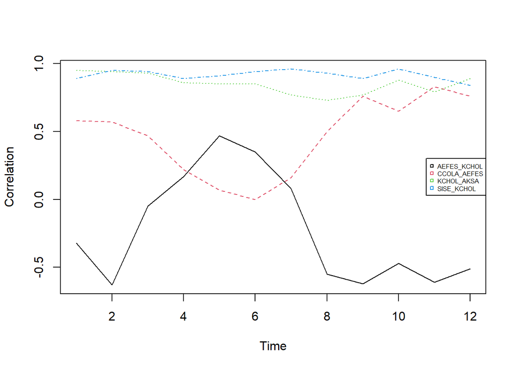

```r
corrByMonthAEFES_KCHOL <- c()
corrByMonthCCOLA_AEFES <- c()
corrByMonthKCHOL_AKSA <- c()
corrByMonthSISE_KCHOL <- c()
i <- 1
for (month in monthList){

  month_df <- subset(wide_filtered, Month == month)
  corrByMonthAEFES_KCHOL[i] <- round(cor(month_df$AEFES,month_df$KCHOL),digits=2)
  corrByMonthCCOLA_AEFES[i] <- round(cor(month_df$CCOLA,month_df$AEFES),digits=2)
  corrByMonthKCHOL_AKSA[i] <- round(cor(month_df$KCHOL,month_df$AKSA),digits=2)
  corrByMonthSISE_KCHOL[i] <- round(cor(month_df$SISE,month_df$KCHOL),digits=2)
  i <- i + 1

}


monthCorrData <- data.frame("Month" = unique(wide_filtered$Month), "AEFES_KCHOL" = corrByMonthAEFES_KCHOL
                ,"CCOLA_AEFES" = corrByMonthCCOLA_AEFES, "KCHOL_AKSA" = corrByMonthKCHOL_AKSA,
                "SISE_KCHOL" = corrByMonthSISE_KCHOL)

monthCorrDataCombined <- data.frame( "AEFES_KCHOL" = monthCorrData[,"AEFES_KCHOL"],
                             "CCOLA_AEFES" = monthCorrData[,"CCOLA_AEFES"],
                             "KCHOL_AKSA" = monthCorrData[,"KCHOL_AKSA"],
                             "SISE_KCHOL" = monthCorrData[,"SISE_KCHOL"])
matplot(y = monthCorrDataCombined, type = "l",pch=1,col = 1:4,
        xlab = "Time", ylab = "Correlation")
legend("right", legend = c("AEFES_KCHOL","CCOLA_AEFES","KCHOL_AKSA","SISE_KCHOL"),
       col=1:4,pch=0.2,cex = 0.5)
```

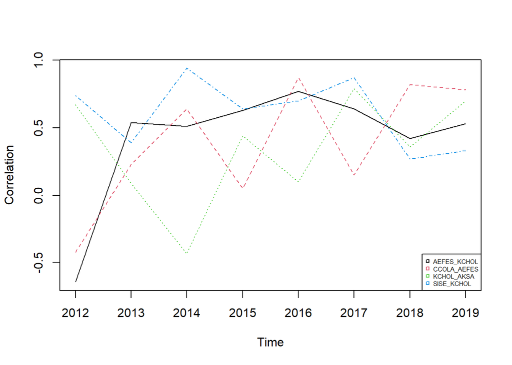

```r
corrByYearAEFES_KCHOL <- c()
corrByYearCCOLA_AEFES <- c()
corrByYearKCHOL_AKSA <- c()
corrByYearSISE_KCHOL <- c()
i <- 1
for (year in yearList){

  year_df <- subset(wide_filtered, Year == year)
  corrByYearAEFES_KCHOL[i] <- round(cor(year_df$AEFES,year_df$KCHOL),digits=2)
  corrByYearCCOLA_AEFES[i] <- round(cor(year_df$CCOLA,year_df$AEFES),digits=2)
  corrByYearKCHOL_AKSA[i] <- round(cor(year_df$KCHOL,year_df$AKSA),digits=2)
  corrByYearSISE_KCHOL[i] <- round(cor(year_df$SISE,year_df$KCHOL),digits=2)
  i <- i + 1

}


yearCorrData <- data.frame("Year" = unique(wide_filtered$Year), "AEFES_KCHOL" = corrByYearAEFES_KCHOL
                            ,"CCOLA_AEFES" = corrByYearCCOLA_AEFES, "KCHOL_AKSA" = corrByYearKCHOL_AKSA,
                            "SISE_KCHOL" = corrByYearSISE_KCHOL)

yearCorrDataCombined <- data.frame( "AEFES_KCHOL" = yearCorrData[,"AEFES_KCHOL"],
                                     "CCOLA_AEFES" = yearCorrData[,"CCOLA_AEFES"],
                                     "KCHOL_AKSA" = yearCorrData[,"KCHOL_AKSA"],
                                     "SISE_KCHOL" = yearCorrData[,"SISE_KCHOL"])
matplot(x=yearCorrData$Year,y = yearCorrData[,-1], type = "l",pch=1,col = 1:4,
        xlab = "Time", ylab = "Correlation")
legend("bottomright", legend = c("AEFES_KCHOL","CCOLA_AEFES","KCHOL_AKSA","SISE_KCHOL"),
       col=1:4,pch=0.2,cex = 0.5)
```

As a general comment, we can say that the correlation values obtained when we examine the stocks by years have both lower and higher variances compared to the evaluations by months. This means that repeating this analysis more often will yield more logical results.

Now let’s move on to the third part of the task, namely dimensionality reduction.

### Task 4.3 : Principal Component Analysis (PCA)

In this part of the task, we will use PCA, one of the dimensionality reduction methods. You will see 3 different PCA objects in the code script below (took a support from lecture notes). The first of these will be a PCA containing 60 columns, and the other two will be a PCA containing 5 stocks of my choice.

```r
pcaObj_all <- princomp(wide[,-1],cor=T)

summary(pcaObj_all)
```

```
## Importance of components:
##                          Comp.1    Comp.2    Comp.3     Comp.4     Comp.5
## Standard deviation     5.521217 3.2138023 2.5338928 1.77732360 1.50499639
## Proportion of Variance 0.508064 0.1721421 0.1070102 0.05264799 0.03775024
## Cumulative Proportion  0.508064 0.6802061 0.7872163 0.83986425 0.87761449
##                            Comp.6     Comp.7     Comp.8      Comp.9     Comp.10
## Standard deviation     1.15665690 0.94288910 0.79534018 0.726608770 0.688710767
## Proportion of Variance 0.02229759 0.01481733 0.01054277 0.008799338 0.007905375
## Cumulative Proportion  0.89991207 0.91472940 0.92527217 0.934071508 0.941976884
##                            Comp.11     Comp.12     Comp.13     Comp.14
## Standard deviation     0.684459130 0.595414216 0.564479439 0.536797476
## Proportion of Variance 0.007808072 0.005908635 0.005310617 0.004802526
## Cumulative Proportion  0.949784955 0.955693590 0.961004207 0.965806733
##                            Comp.15     Comp.16     Comp.17     Comp.18
## Standard deviation     0.495967107 0.430519178 0.413788051 0.379905036
## Proportion of Variance 0.004099723 0.003089113 0.002853676 0.002405464
## Cumulative Proportion  0.969906456 0.972995569 0.975849244 0.978254708
##                            Comp.19     Comp.20     Comp.21     Comp.22
## Standard deviation     0.369193850 0.333013120 0.312997099 0.289459209
## Proportion of Variance 0.002271735 0.001848296 0.001632786 0.001396444
## Cumulative Proportion  0.980526443 0.982374739 0.984007525 0.985403969
##                            Comp.23     Comp.24     Comp.25      Comp.26
## Standard deviation     0.272105721 0.262420843 0.251952282 0.2395486086
## Proportion of Variance 0.001234025 0.001147745 0.001057999 0.0009563923
## Cumulative Proportion  0.986637995 0.987785740 0.988843739 0.9898001311
##                             Comp.27      Comp.28      Comp.29      Comp.30
## Standard deviation     0.2357950930 0.2229898985 0.2138778536 0.2063737735
## Proportion of Variance 0.0009266554 0.0008287416 0.0007623956 0.0007098356
## Cumulative Proportion  0.9907267865 0.9915555281 0.9923179237 0.9930277593
##                             Comp.31      Comp.32      Comp.33      Comp.34
## Standard deviation     0.1962254625 0.1936812712 0.1812237580 0.1716208727
## Proportion of Variance 0.0006417405 0.0006252072 0.0005473675 0.0004908954
## Cumulative Proportion  0.9936694998 0.9942947071 0.9948420746 0.9953329700
##                             Comp.35     Comp.36      Comp.37      Comp.38
## Standard deviation     0.1689252870 0.157314846 0.1481436206 0.1409458470
## Proportion of Variance 0.0004755959 0.000412466 0.0003657755 0.0003310955
## Cumulative Proportion  0.9958085659 0.996221032 0.9965868074 0.9969179029
##                             Comp.39      Comp.40      Comp.41      Comp.42
## Standard deviation     0.1350716230 0.1292517726 0.1204368445 0.1183908911
## Proportion of Variance 0.0003040724 0.0002784337 0.0002417506 0.0002336067
## Cumulative Proportion  0.9972219753 0.9975004090 0.9977421596 0.9979757663
##                             Comp.43      Comp.44      Comp.45      Comp.46
## Standard deviation     0.1140603496 0.1068477112 0.1043264395 0.1031564022
## Proportion of Variance 0.0002168294 0.0001902739 0.0001814001 0.0001773541
## Cumulative Proportion  0.9981925957 0.9983828696 0.9985642697 0.9987416237
##                             Comp.47      Comp.48      Comp.49      Comp.50
## Standard deviation     0.0978073813 0.0913568396 0.0870584938 0.0859096047
## Proportion of Variance 0.0001594381 0.0001391012 0.0001263197 0.0001230077
## Cumulative Proportion  0.9989010618 0.9990401630 0.9991664827 0.9992894903
##                             Comp.51      Comp.52      Comp.53      Comp.54
## Standard deviation     0.0784365377 0.0777472381 7.253500e-02 6.925466e-02
## Proportion of Variance 0.0001025382 0.0001007439 8.768876e-05 7.993681e-05
## Cumulative Proportion  0.9993920285 0.9994927724 9.995805e-01 9.996604e-01
##                             Comp.55      Comp.56      Comp.57      Comp.58
## Standard deviation     6.649994e-02 6.367317e-02 6.076481e-02 5.642499e-02
## Proportion of Variance 7.370403e-05 6.757121e-05 6.153938e-05 5.306298e-05
## Cumulative Proportion  9.997341e-01 9.998017e-01 9.998632e-01 9.999163e-01
##                             Comp.59      Comp.60
## Standard deviation     0.0517369125 4.844334e-02
## Proportion of Variance 0.0000446118 3.911262e-05
## Cumulative Proportion  0.9999608874 1.000000e+00
```

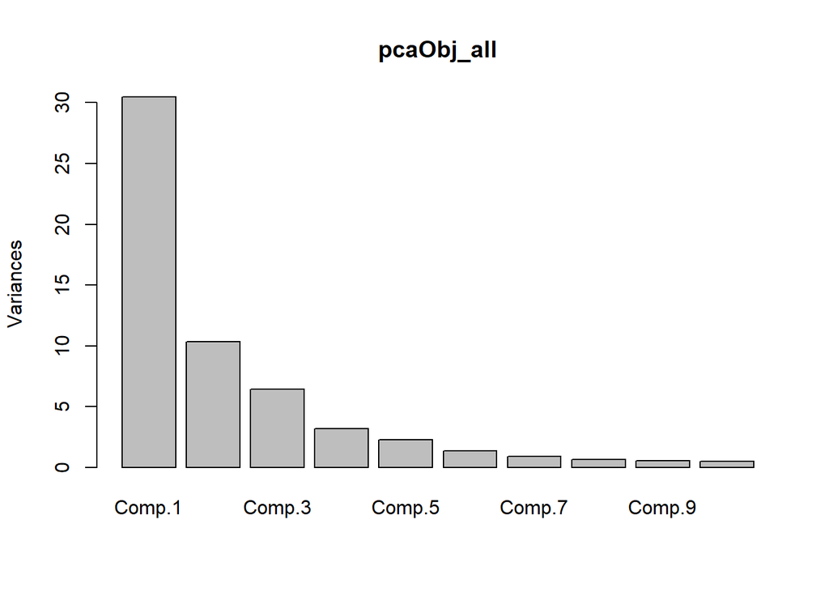

```r
plot(pcaObj_all)
```

When we examine the PCA object we created with the data containing all stocks, we can cover more than 90% of the variance with the first 7 components. I did not printed the loadings of this PCA summary but I have analyzed in detail. Even though first 2 components can explain almost 70% of the variance of data, their linear function is quite complicated and there are no specific latent variables I could say.

Stocks with high correlation tends to have same coefficient in PC linear equation such as ARCLK and AKBNK. Their sector are different, it might be affected by the stock volume etc.

Let’s also do PCA for the selected stocks in my assignment:

```r
pcaObj <- princomp(wide_filtered[,-1:-3],cor=T)
summary(pcaObj, loadings = T)
```

```
## Importance of components:
##                           Comp.1    Comp.2     Comp.3     Comp.4    Comp.5
## Standard deviation     1.7693593 1.0937146 0.62224016 0.46496201 0.2641657
## Proportion of Variance 0.6261265 0.2392423 0.07743656 0.04323793 0.0139567
## Cumulative Proportion  0.6261265 0.8653688 0.94280536 0.98604330 1.0000000
##
## Loadings:
##       Comp.1 Comp.2 Comp.3 Comp.4 Comp.5
## AEFES  0.170  0.813  0.554
## AKSA  -0.483  0.316 -0.287 -0.732 -0.221
## CCOLA  0.414  0.436 -0.762  0.233
## SISE  -0.530  0.138         0.583 -0.600
## KCHOL -0.535  0.173 -0.171  0.264  0.764
```

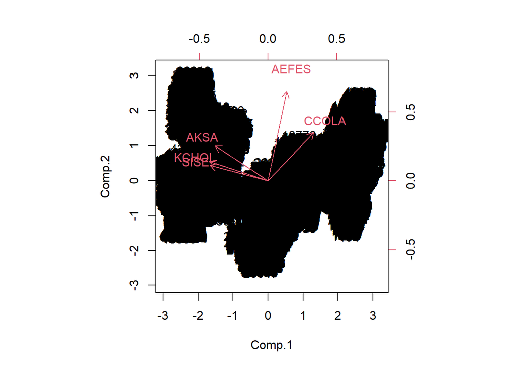

```r
biplot(pcaObj, scale = 0)
```

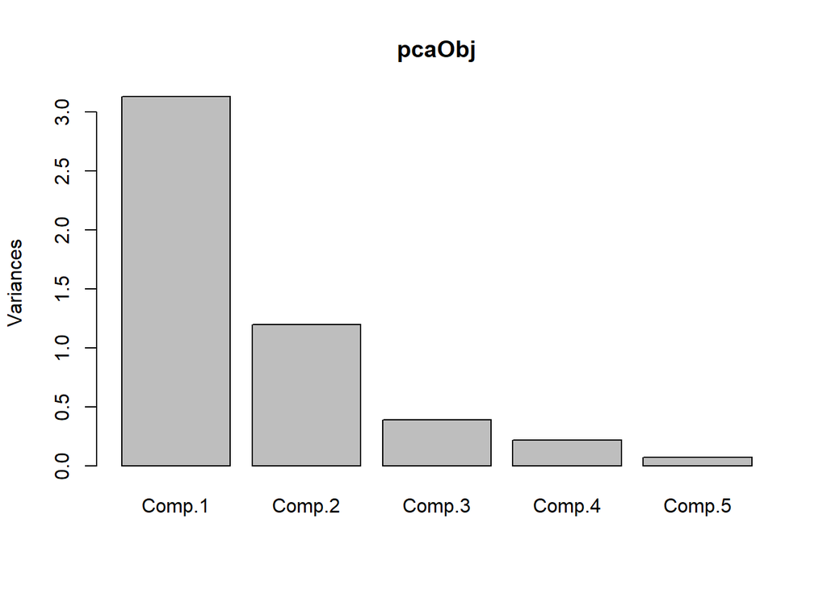

```r
plot(pcaObj)
```

```r
logPcaObj <- princomp(log(wide_filtered[,-1:-3]),cor=T)
summary(logPcaObj, loadings = T)
```

```
## Importance of components:
##                           Comp.1    Comp.2     Comp.3     Comp.4      Comp.5
## Standard deviation     1.7800271 1.0741799 0.69975481 0.37261032 0.221688287
## Proportion of Variance 0.6336993 0.2307725 0.09793136 0.02776769 0.009829139
## Cumulative Proportion  0.6336993 0.8644718 0.96240317 0.99017086 1.000000000
##
## Loadings:
##       Comp.1 Comp.2 Comp.3 Comp.4 Comp.5
## AEFES  0.214  0.768  0.593  0.110
## AKSA  -0.487  0.310 -0.362  0.724  0.108
## CCOLA  0.378  0.494 -0.718 -0.306
## SISE  -0.539  0.176        -0.306 -0.764
## KCHOL -0.532  0.198        -0.526  0.633
```

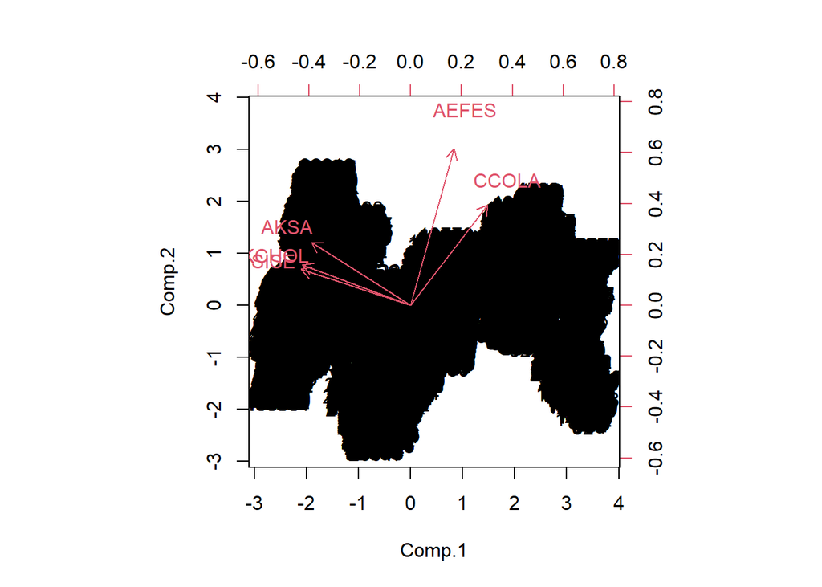

```r
biplot(logPcaObj, scale = 0)
```

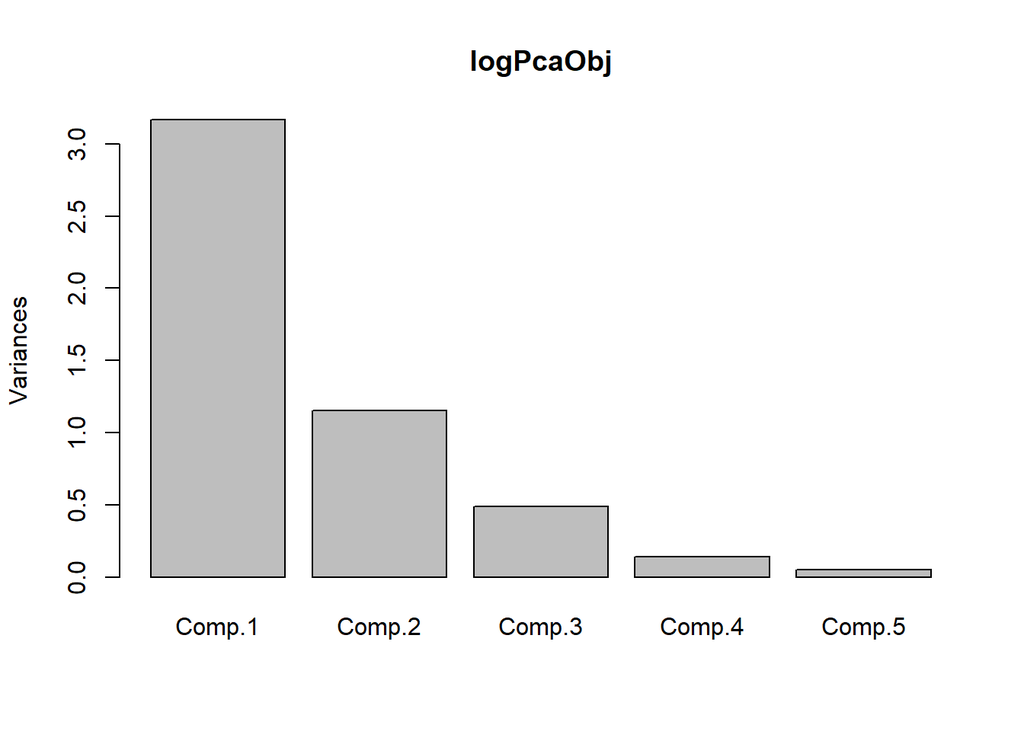

```r
plot(logPcaObj)
```

For the first PCA object created using 5 stocks, Its 3 component can cover almost 95% of the variance.

- PC1: First principal component can explain SISE and KCHOL data most since the coefficients in the equation are highest (abs value). Also, we can say that there are latent variables such as [`KCHOL`,`SISE`,`AKSA`] & [`AEFES`,`CCOLA`]. It means that when KCHOL’s stock price is high or low, AKSA and SISE are in a similar downward and upward trend. Vice versa for AEFES & CCOLA
- PC2: Second principal component emphasizes the AFESE mostly and then CCOLA. It covers the variation of these specific stocks.

In the first plot, which is the rotations of the eigenvectors, [`KCHOL`,`SISE`,`AKSA`] looks like the same direction, covering the similar data var, whereas [`AEFES`,`CCOLA`] is on another direction. (Data points look annoying, I could not find a way to beautify it, also I have find ‘biplot’ usage from internet).

Histogram basically shows the variances of principal components, its covered variance is decreasing as expected.

For the second PCA object using log values of these 5 stocks, Its 3 components can cover almost 96 of the variance, little bit higher than first.

But, its’ PC variables and equations carry similar kind of information with first one. Since the logarithm operation can violate some assumption such as normality, linearity, I think that tradeoff between coverage of variance and loss of assumption is not acceptable.

Thus, we can use the first pca object (pcaObj) with at most 3 components (2 is also acceptable depending on the situation). Using these principal components, we can effectively reduce the dimension of the data and preparing input features for possible forward learning application such as clustering.

Now, we can move on to the final part of the assignment.

### Task 4.4 : Inference with Google Trends

In the last part of the task, we are going to analyze the Google Trends data and compare the results/visualization with the work we’ve already done in the previous parts.

In https://trends.google.com/trends/, I have searched for the keywords `IST:AEFES`,`IST:AKSA`,`IST:CCOLA`,`IST:SISE` and `IST:KCHOL` and filter the dates from 2012-10 to 2019-07. Then, downloaded the corresponding 5 csv files. Let’s upload these csv files to the R environment:

```r
google_aefes <-
          fread("C:/Users/anil.turgut/Desktop/IE582/HW1/Dataset/GoogleTrend/multiTimelineAEFES.csv")
google_aksa <-
  fread("C:/Users/anil.turgut/Desktop/IE582/HW1/Dataset/GoogleTrend/multiTimelineAKSA.csv")
google_ccola <-
  fread("C:/Users/anil.turgut/Desktop/IE582/HW1/Dataset/GoogleTrend/multiTimelineCCOLA.csv")
google_sise <-
  fread("C:/Users/anil.turgut/Desktop/IE582/HW1/Dataset/GoogleTrend/multiTimelineSISE.csv")
google_kchol <-
  fread("C:/Users/anil.turgut/Desktop/IE582/HW1/Dataset/GoogleTrend/multiTimelineKCHOL.csv")

df_google <- data.frame("Time"=google_aefes[,1], "AEFES"=google_aefes[,-1], "AKSA"=google_aksa[,-1],
                        "CCOLA"=google_ccola[,-1],"SISE"=google_sise[,-1], "KCHOL"=google_kchol[,-1])

colnames(df_google) <- c("Month","AEFES","AKSA","CCOLA","SISE","KCHOL")

head(df_google)
```

```
##     Month AEFES AKSA CCOLA SISE KCHOL
## 1 2012-10     0   19    10   11     0
## 2 2012-11     0   20     0   24     9
## 3 2012-12    26   16    10   18     8
## 4 2013-01     0   17    13   28     0
## 5 2013-02    11   16    15   23    22
## 6 2013-03    11   22     6   10    10
```

Now, I have created a “Year” column from splitting the “Month” column. Also, each stock column contains its own volume values.

```r
for (ind in 1:nrow(df_google)){
  df_google[["Year"]][ind] <- strsplit(df_google[["Month"]][ind], "-")[[1]][1]
}

df_google <- df_google[, c("Month","Year","AEFES","AKSA","CCOLA","SISE","KCHOL")]
df_google_month <- df_google[, c("Month","AEFES","AKSA","CCOLA","SISE","KCHOL")]

df_google_month
```

```
##      Month AEFES AKSA CCOLA SISE KCHOL
## 1  2012-10     0   19    10   11     0
## 2  2012-11     0   20     0   24     9
## 3  2012-12    26   16    10   18     8
## 4  2013-01     0   17    13   28     0
## 5  2013-02    11   16    15   23    22
## 6  2013-03    11   22     6   10    10
## 7  2013-04    12   13    32   25     0
## 8  2013-05    32   17    10   16    12
## 9  2013-06     0   15     9   15     8
## 10 2013-07    12   26    10   27    19
## 11 2013-08    22   11     6   11     6
## 12 2013-09     0   25    11   10     9
## 13 2013-10    31   30    15   15     9
## 14 2013-11    47   21    30   20     0
```

[output cut: 68 more lines]

Visualization of 5 stocks in line chart can be seen below:

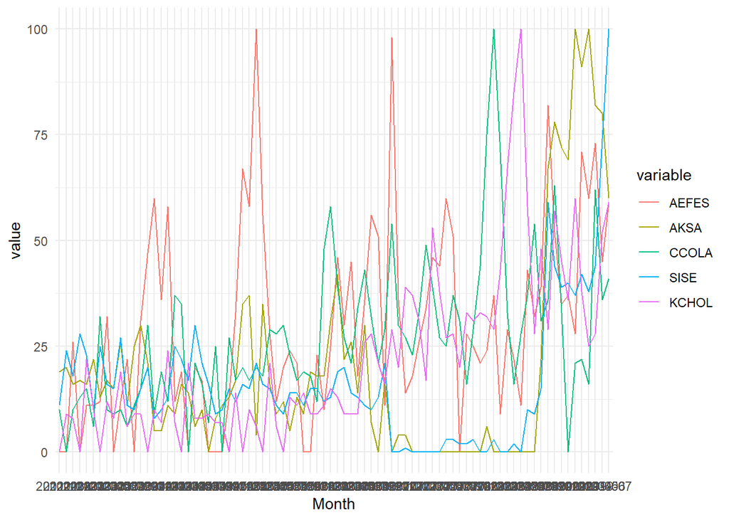

```r
# Line chart of 5 stocks in google trend
df_google_combined <- data.table::melt(df_google_month, id.var = "Month")


ggplot(df_google_combined, aes(x = Month, y = value, color = variable, group=variable)) +
  geom_line() +
  theme_minimal()
```

Finally, I have created a dataframe containing the correlation values between 5 stocks grouped by years (similar in Task 4.2). And visualized it through multiple line chart.

```r
corrGoogleByYearAEFES_KCHOL <- c()
corrGoogleByYearCCOLA_AEFES <- c()
corrGoogleByYearKCHOL_AKSA <- c()
corrGoogleByYearSISE_KCHOL <- c()
i <- 1
for (year in unique(df_google$Year)){

  year_df <- subset(df_google, Year == year)
  corrGoogleByYearAEFES_KCHOL[i] <- round(cor(year_df$AEFES,year_df$KCHOL),digits=2)
  corrGoogleByYearCCOLA_AEFES[i] <- round(cor(year_df$CCOLA,year_df$AEFES),digits=2)
  corrGoogleByYearKCHOL_AKSA[i] <- round(cor(year_df$KCHOL,year_df$AKSA),digits=2)
  corrGoogleByYearSISE_KCHOL[i] <- round(cor(year_df$SISE,year_df$KCHOL),digits=2)
  i <- i + 1

}

googleYearCorrData <- data.frame("Year" = unique(df_google$Year), "AEFES_KCHOL" = corrGoogleByYearAEFES_KCHOL
                           ,"CCOLA_AEFES" = corrGoogleByYearCCOLA_AEFES, "KCHOL_AKSA" = corrGoogleByYearKCHOL_AKSA,
                           "SISE_KCHOL" = corrGoogleByYearSISE_KCHOL)
googleYearCorrData
```

```
##   Year AEFES_KCHOL CCOLA_AEFES KCHOL_AKSA SISE_KCHOL
## 1 2012        0.41        0.50      -0.18       0.93
## 2 2013       -0.07        0.17       0.17      -0.03
## 3 2014        0.38        0.15       0.09      -0.19
## 4 2015       -0.37       -0.16      -0.36      -0.01
## 5 2016        0.66        0.13      -0.48      -0.60
## 6 2017        0.18        0.09       0.23      -0.35
## 7 2018       -0.44       -0.05      -0.22      -0.30
## 8 2019       -0.54        0.55      -0.26       0.58
```

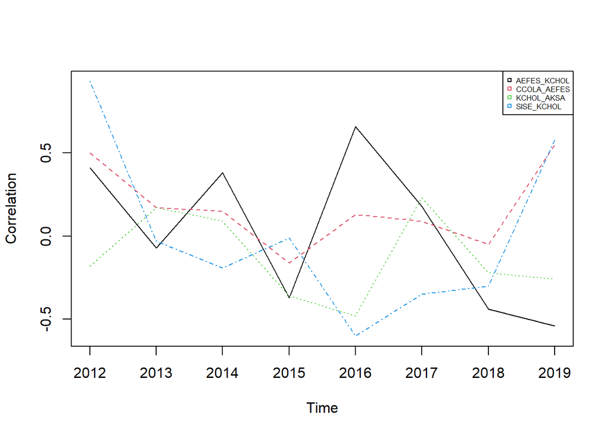

```r
matplot(x=googleYearCorrData$Year,y = googleYearCorrData[,-1], type = "l",pch=1,col = 1:4,
        xlab = "Time", ylab = "Correlation")
legend("topright", legend = c("AEFES_KCHOL","CCOLA_AEFES","KCHOL_AKSA","SISE_KCHOL"),
       col=1:4,pch=0.2,cex = 0.5)
```

Let’s also plot the correlation multiple line chart we’ve created in the Task4.2

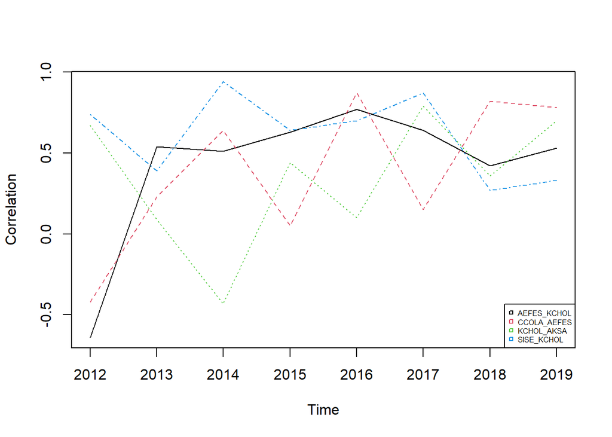

```r
matplot(x=yearCorrData$Year,y = yearCorrData[,-1], type = "l",pch=1,col = 1:4,
        xlab = "Time", ylab = "Correlation")
legend("bottomright", legend = c("AEFES_KCHOL","CCOLA_AEFES","KCHOL_AKSA","SISE_KCHOL"),
       col=1:4,pch=0.2,cex = 0.5)
```

After comparing 2 graphs, there are some similar patterns between stock pair correlations, but mostly they are different in terms of values. Price correlation vs. Volume of visited/search correlation might be independent from each other. That’s also different insight of this work.

### Conclusion

In this assignment, we tried to examine in detail 60 different stocks and their closing prices between 2012-2019. First, we worked on data preprocessing, then correlation analysis and dimensionality reduction (PCA) to do data mining. Finally, we tried to make an inference with the data we obtained from Google Trend.

A predictive analysis can be made by organizing these outputs and using them as input in a suitable model/algorithm, and then the quality of the work can be tested again with the metrics we will reach.

```
                                                                                      `Anıl Turgut - 2022702072`
```